# Distribución geométrica

Téllez Gerardo Rubén

3/2/2022

Modela el número de intentos necesarios para obtener un éxito, o el número de fracasos antes de tener el primer éxito.

# V.A.

Si $X$ es variable aleatoria que mide el “número de repeticiones independientes del experimento hasta haber conseguido un éxito”, diremos que $X$ se distribuye como una Geométrica con parámetro $p$

$$X \sim He(p)$$

donde $p$ es la probabilidad de éxito y $q = 1 - q$ es la probabilidad de fracaso.

- El **dominio** de $X$ será $D_X = \{0, 1, 2, \dots n\}$ o bien $D_X = \{1, 2, \dots n\}$ en función de si empieza en 0 o en 1 respectivamente.
- La **función de densidad** vendrá dada por

$$f(k) = p(X = k) = (1 - p)^kp\ \ \ si\ empieza\ en\ 0$$
$$f(k) = p(X=k) = (1 - p)^{k-1}p\ \ \ si\ empieza\ en\ 1$$

Se fallan k veces hasta el primer éxito.

*Otra variante mide el número de fracasos*

- La *función de distribución* vendrá dada por:

$$F(x) = \Bigg \{ \begin{matrix} 0 & si\ x < 0 \\ 1-(1 - p)^{k+1} & si\ k \le x \le k+1, k \in \mathbb{N} \end{matrix}$$

- *Esperanza* $E(X) = \frac{1-p}{p}$ si empieza en 0 y $E(X) = \frac{1}{p}$ si empieza en 1.
- *Varianza* $Var(X) = \frac{1-p}{p^2}$
- **Propiedad de la falta de memoria**: Si $X$ es una v.a. $Ge(p)$, entonces:

$$p\{X \ge m + n : X \le n\} = p \{X \ge m\} \forall m, n = D_X$$

Si se prueban $n$ veces más, estas son igual de probables que las anteriores.

## Función de probabilidad de una Ge(0,5)

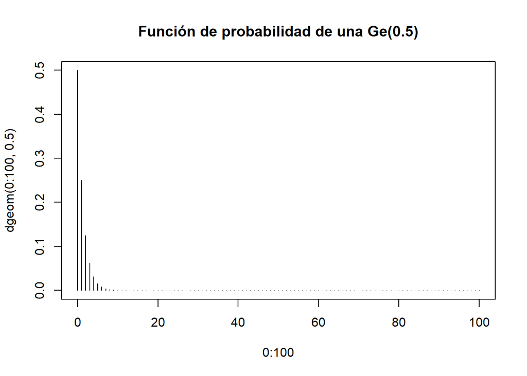

```r
plot(dgeom(0:100, 0.5), type="h", main="Función de probabilidad de una Ge(0.5)", x=0:100)
```

## Función de distribución de una Ge(0.5)

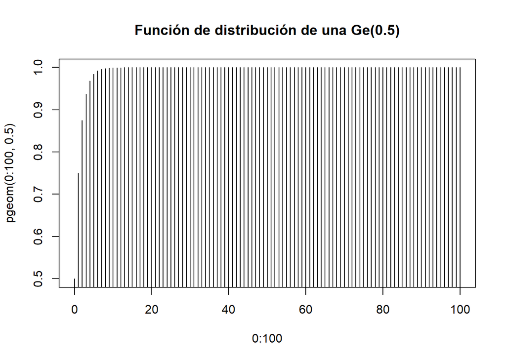

```r
plot(pgeom(0:100, 0.5), type="h", main="Función de distribución de una Ge(0.5)", x=0:100)
```

## Código de la Distribución

El código de la distribución Geométrica:

- En **R** tenemos las funciones del paquete `dgeom(x, prob), pgeom(q, prob), qgeom(p, prob), rgeom(n, prob)` donde `prob` es la probabilidad de éxito del experimento.
- En `Python` tenemos las funciones del paquete `scipy.stats.geom: pmf(k,p), cdf(k,p), ppf(q,p), rvs(p,size)`, donde `p` es la probabilidad de éxito del experimento.

## Función de densidad

Sea $X \sim p(p = 0.1)$ la distribución que modela la probabilidad de intentar abrir una puerta hasta conseguirlo.

$$f(k) = (1-p)^{k-1}$$

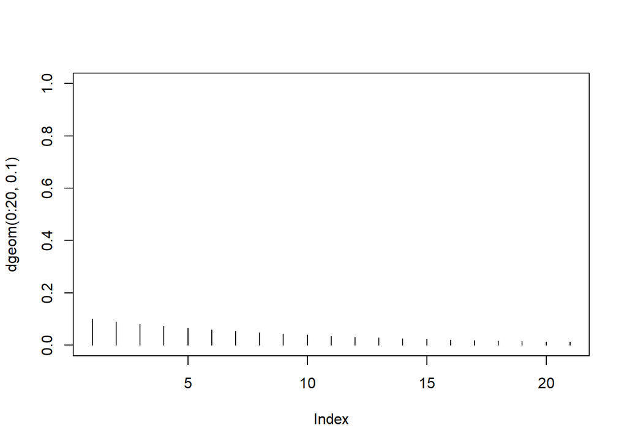

```r
p = 0.1
plot(dgeom(0:20,0.1), type="h", ylim=c(0,1))
```

## Función de distribución

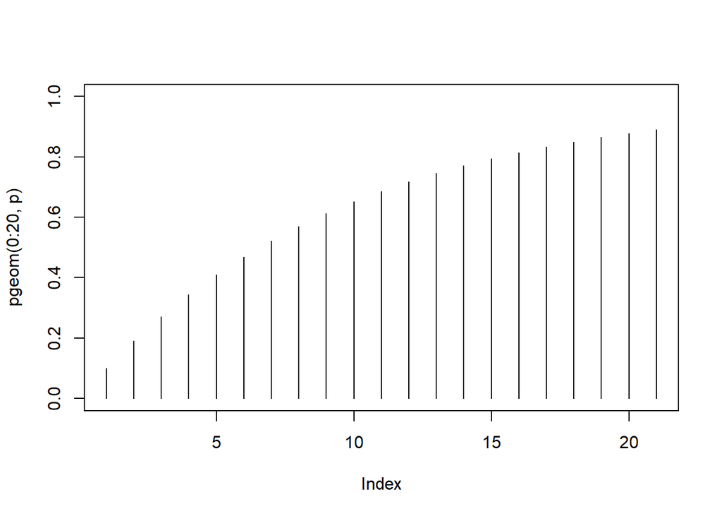

```r
plot(pgeom(0:20, p), ylim=c(0,1), type="h")
```

## Cuantiles

```r
qgeom(0.5, p) #Con 6 intentos sería más probable que hubiera abierto que haber fallado
```

```
## [1] 6
```

```r
qgeom(0.75, p)
```

```
## [1] 13
```

## Aleatorios

```r
rgeom(10, p)
```

```
##  [1]  4 10  0  4  1 12  2  7  5 29
```

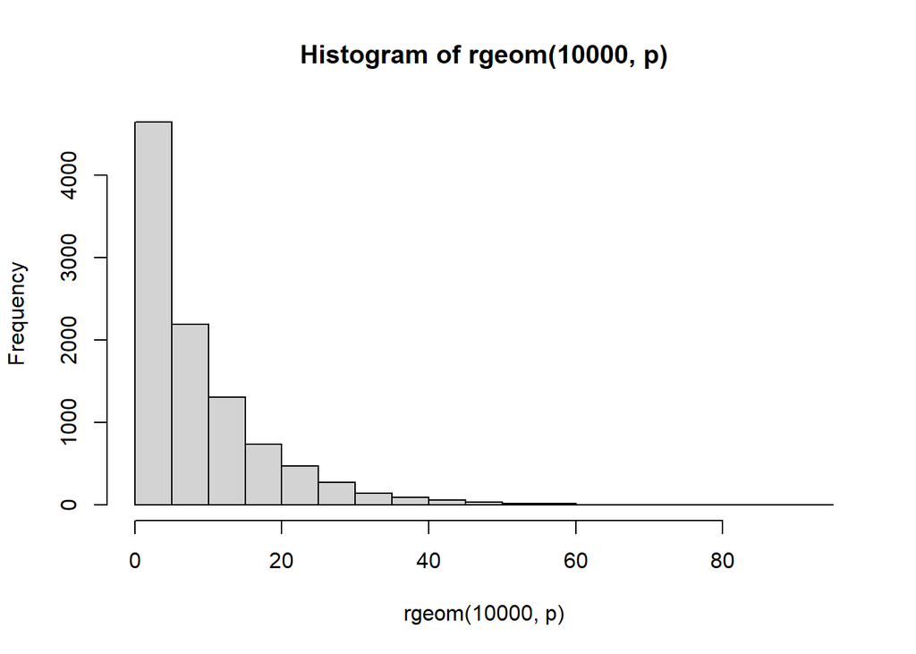

```r
hist(rgeom(10000, p))
```

# En python

```python
from scipy.stats import geom
import matplotlib.pyplot as plt
import numpy as np


fig, ax = plt.subplots(1,1)
p = 0.3
mean, var, skew, kurt = geom.stats(p, moments="mvsk")

print("Media:", mean)
```

```
## Media: 3.3333333333333335
```

```python
print("Varianza:", var)
```

```
## Varianza: 7.777777777777779
```

```python
print("Sesgo:", skew)
```

```
## Sesgo: 2.031888635868469
```

```python
print("Curtosis:", kurt)
```

```
## Curtosis: 6.128571428571429
```

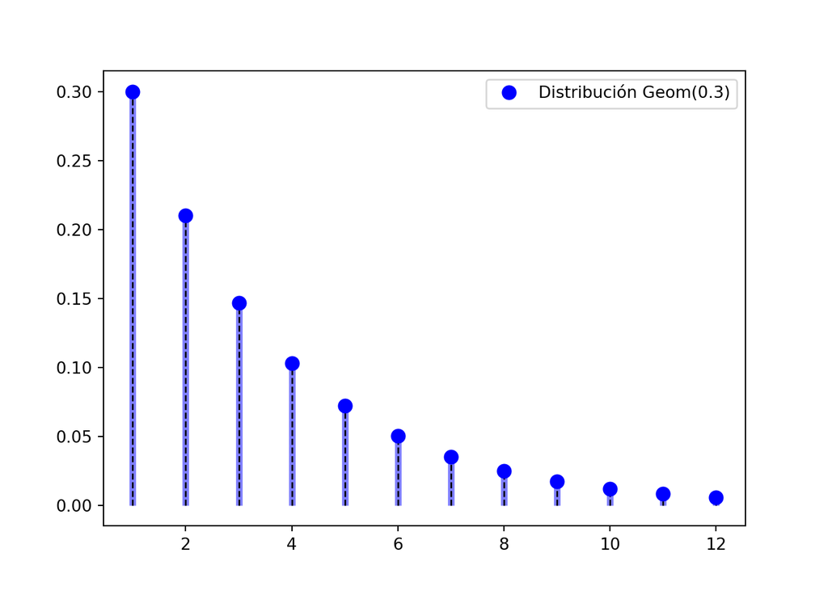

```python
x = np.arange(geom.ppf(0.01, p), geom.ppf(0.99, p))
ax.plot(x, geom.pmf(x,p), "bo", ms=8, label="Distribución Geom(0.3)")
ax.vlines(x,0,geom.pmf(x,p), colors="b", lw=4, alpha=0.5)
ax.legend(loc="best")
rv = geom(p)
ax.vlines(x,0,rv.pmf(x), colors="k", linestyles="--", lw=1, label="Frozen PMF")
plt.show()
```

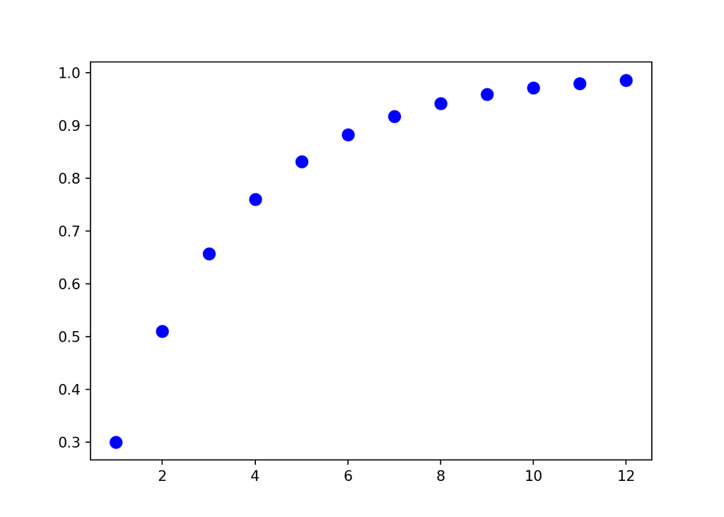

```python
fig, ax = plt.subplots(1,1)
prob = geom.cdf(x,p)
ax.plot(x,prob,"bo",ms=8, label="Función de distribución acumulada")
plt.show()
```

```python
fig, ax=plt.subplots(1,1)
r = geom.rvs(p, size=10000)
plt.hist(r)
```

```
## (array([6.523e+03, 1.835e+03, 1.068e+03, 2.680e+02, 1.640e+02, 9.800e+01,
##        2.300e+01, 1.200e+01, 7.000e+00, 2.000e+00]), array([ 1. ,  3.4,  5.8,  8.2, 10.6, 13. , 15.4, 17.8, 20.2, 22.6, 25. ]), <BarContainer object of 10 artists>)
```

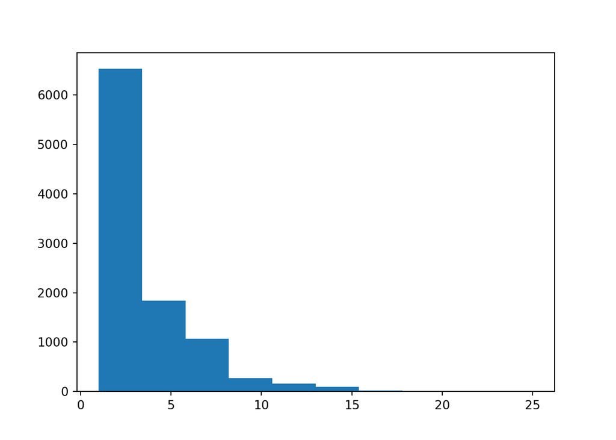

```python
plt.show()
```